# Assignment: Spatial Diversity

Roy Z Moger-Reischer; Z620: Quantitative Biodiversity, Indiana University

05 February, 2017

## OVERVIEW

This assignment will emphasize primary concepts and patterns associated with spatial diversity, while using R as a Geographic Information Systems (GIS) environment. Complete the assignment by refering to examples in the handout.

After completing this assignment you will be able to:  
1. Begin using R as a geographical information systems (GIS) environment.  
2. Identify primary concepts and patterns of spatial diversity.  
3. Examine effects of geographic distance on community similarity.  
4. Generate simulated spatial data.

## Directions:

1. Change “Student Name” on line 3 (above) with your name.
2. Complete as much of the assignment as possible during class; what you do not complete in class will need to be done on your own outside of class.
3. Use the handout as a guide; it contains a more complete description of data sets along with the proper scripting needed to carry out the assignment.
4. Be sure to **answer the questions** in this assignment document. Space for your answer is provided in this document and indicated by the “>” character. If you need a second paragraph be sure to start the first line with “>”.
5. Before you leave the classroom, **push** this file to your GitHub repo.
6. When you are done wit the assignment, **Knit** the text and code into an html file.
7. After Knitting, please submit the completed assignment by creating a **pull request** via GitHub. Your pull request should include this file *spatial_assignment.Rmd* and the html output of `Knitr` (*spatial_assignment.html*).

## 1) R SETUP

In the R code chunk below, provide the code to:

1. Clear your R environment
2. Print your current working directory,
3. Set your working directory to your “*/Week4-Spatial*” folder, and

```r
rm(list=ls())
getwd()
#setwd
```

## 2) LOADING R PACKAGES

In the R code chunk below, do the following:

1. Install and/or load the following packages: `vegan`, `sp`, `gstat`, `raster`, `RgoogleMaps`, `maptools`, `rgdal`, `simba`, `gplots`, `rgeos`

```r
#vegan

#install.packages("vegan")
require(vegan)
#install.packages('sp') # Classes and methods for handling spatial data
require(sp)
#install.packages('gstat') # geostatistical analyses
require(gstat)
#install.packages('raster') # create a RasterLayer object
require(raster)
#install.packages('RgoogleMaps') #find Google server for static maps.
require(RgoogleMaps)
#install.packages('maptools') # Tools for geospatial data
require(maptools)
#install.packages('rgdal') # Geospatial Data Abstraction Library
require(rgdal)
#install.packages('simba')
require("simba")
#install.packages('gplots')
require("gplots")


? simba
? rgdal
? sp
#install.packages("ggplot2")
require(ggplot2)
```

*Question 1*: What are the packages `simba`, `sp`, and `rgdal` used for?

> *Answer 1*:

> simba: “Calculate similarity measures for binary data.” That is, if we have species data in binary format, we can calculate (dis)similarity metrics.

> sp: This package helps turn R into a GIS software. It defines classes that represent point data, line data, shape data, coordinates data. It looks like this could help R interpret GIS shapefiles and the like.

> rgdal: there was no automatic documentation for this package. It looks like this a package that interfaces with sp to be able to read shapefiles and interpret a coordinate reference system and projections.

## 3) LOADING DATA

In the R code chunk below, use the example in the handout to do the following:

1. Load the Site-by-Species matrix for the Indiana ponds datasets: BrownCoData/SiteBySpecies.csv
2. Load the Environmental data matrix: BrownCoData/20130801_PondDataMod.csv
3. Assign the operational taxonomic units (OTUs) to a variable ‘otu.names’
4. Remove the first column (i.e., site names) from the OTU matrix.

```r
Ponds <- read.table(file = "BrownCoData/20130801_PondDataMod.csv", head = TRUE, sep = ",")
lats <- as.numeric(Ponds[, 3]) # latitudes (north and south)
lons <- as.numeric(Ponds[, 4]) # longitudes (east and west)
OTUs <- read.csv(file = "BrownCoData/SiteBySpecies.csv", head = TRUE, sep = ",")
otu.names = names(OTUs)
OTUs<-as.data.frame(OTUs[-1])
str(OTUs)
S.obs <- function(x=""   ){
   rowSums(x>0) *1
}#for each row x, take the sum of columns for whcih x > 0
max(S.obs(OTUs))
```

*Question 2a*: How many sites and OTUs are in the SiteBySpecies matrix?

> *Answer 2a*: There are 51 sites. There are 16384-1=16383 distinct OTUs.

*Question 2b*: What is the greatest species richness found among sites?

> *Answer 2b*: 3659

## 4) GENERATE MAPS

In the R code chunk below, do the following:

1. Using the example in the handout, visualize the spatial distribution of our samples with a basic map in RStudio using the `GetMap` function in the package `RgoogleMaps`. This map will be centered on Brown County, Indiana (39.1 latitude, -86.3 longitude).

[figure not shown]

```r
newmap <- GetMap(center = c(39.1,-86.3), zoom = 10,destfile = "PondsMap.png", maptype="terrain")
PlotOnStaticMap(newmap, zoom = 10, cex = 2, col = 'blue') # Plot map in RStudio
PlotOnStaticMap(newmap, lats, lons, cex = 1, pch = 20, col = 'red', add = TRUE)
```

*Question 3*: Briefly describe the geographical layout of our sites.

> *Answer 3*: There are 3 main spatial clusters of sites (north central, south central, northeast). There are also small clusters of sites to the southeast and southwest, with one single site located in the northwest. Some are nearer to water than others.

In the R code chunk below, do the following:

1. Using the example in the handout, build a map by combining lat-long data from our ponds with land cover data and data on the locations and shapes of surrounding water bodies.

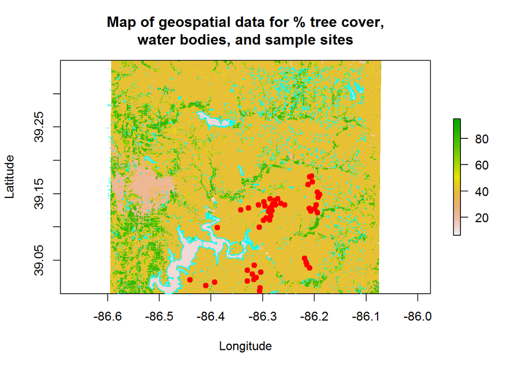

```r
# 1. Import TreeCover.tif as a raster file.
Tree.Cover <- raster("TreeCover/TreeCover.tif")


# 2. Plot the % tree cover data
plot(Tree.Cover, xlab = 'Longitude', ylab = 'Latitude',
main = 'Map of geospatial data for % tree cover,\nwater bodies, and sample sites')
# 3. Import water bodies as a shapefile.
Water.Bodies <- readShapeSpatial("water/water.shp")
# 4. Plot the water bodies around our study area, i.e., Monroe County.
plot(Water.Bodies, border='cyan', axes = TRUE, add = TRUE)
# 5. Convert lat-long data for ponds to georeferenced points.
Refuge.Ponds <- SpatialPoints(cbind(lons, lats))
# 6. Plot the refuge pond locations
plot(Refuge.Ponds, line='r', col='red', pch = 20, cex = 1.5, add = TRUE)
```

*Question 4a*: What are datums and projections?

> *Answer 4a*: A datum defines the shape of Earth’s surface. Then a projection maps that 3D shape onto a 2D surface.

## 5) UNDERSTANDING SPATIAL AUTOCORRELATION

*Question 5*: In your own words, explain the concept of spatial autocorrelation.

> *Answer 5*: At its simplest, spatial autocorrelation means that the values for some phenotype for each of two points in space are not independent of the distance between the two points.

## 6) EXAMINING DISTANCE-DECAY

*Question 6*: In your own words, explain what a distance decay pattern is and what it reveals.

> *Answer 6*: Two points that are near one another in space are more likely to share similar characteristics than are two points which are no near one another. if you compare, pairwise, the entire population of points, you should observe this pattern for all pairs of close points having a higher similarity score than the pairs distal points. The rate (slope) of change of extent of autocorrelation could be displayed as curve; this curve represents the “decay.”

In the R code chunk below, do the following:

1. Generate the distance decay relationship for bacterial communities of our refuge ponds and for some of the environmental variables that were measured. Note: You will need to use some of the data transformations within the *semivariogram* section of the handout.

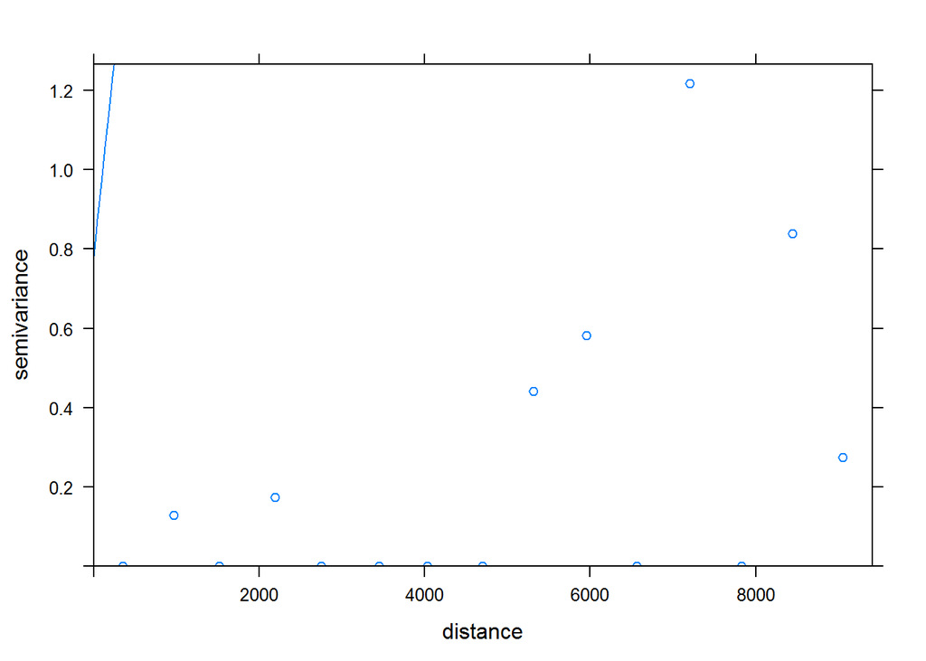

```r
# 1) Calculate Bray-Curtis similarity between plots using the `vegdist()` function
comm.dist <- 1 - vegdist(OTUs)#this is Bray-Curtis similarity
# 2) Assign UTM lattitude and longitude data to 'lats' and 'lons' variables
xy <- data.frame(pond.name = Ponds$Sample_ID, lats = Ponds$lat, lons = Ponds$long)
coordinates(xy) <- ~lats+lons#lat-lon dataframe
# Identify the current projection
proj4string(xy) <- CRS("+proj=longlat +datum=NAD83")
# Transform the projection and data to UTM
UTM <- spTransform(xy, CRS("+proj=utm +zone=51 +ellps=WGS84"))
UTM <- as.data.frame(UTM)
Ponds$lats_utmm <- UTM[,2] # latitude data
Ponds$lons_utmm <- UTM[,3] # longitude data
coordinates(Ponds) = ~lats_utmm+lons_utmm
vgm <- variogram(TDS~1, data=Ponds)
vgm.fit = fit.variogram(vgm, model = vgm(1, "Sph", 900, 1,fit.sill=F, fit.range=F))
plot(vgm, vgm.fit)
```

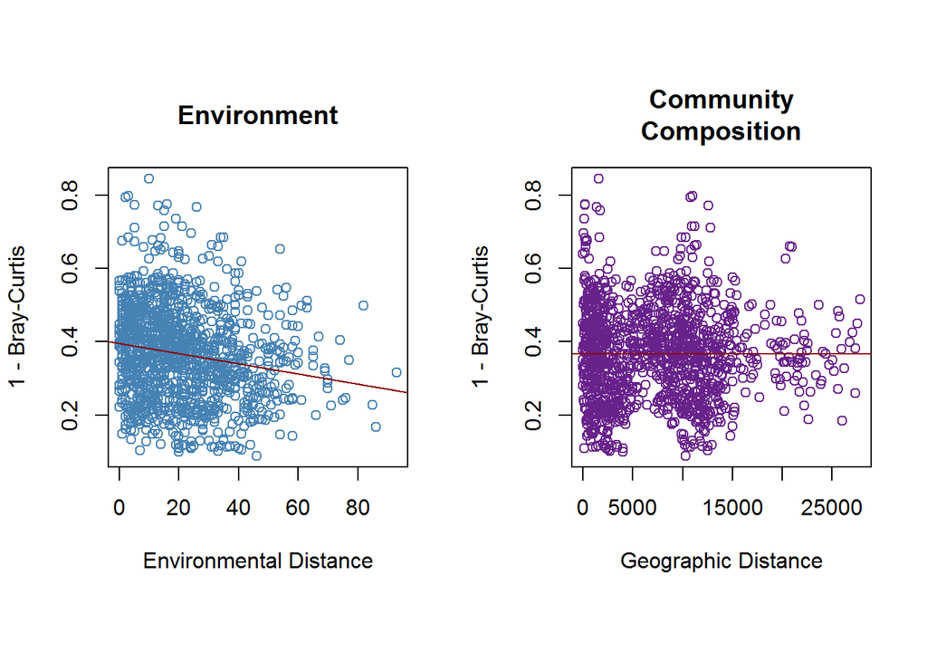

```r
lats <- as.numeric(Ponds$lats_utmm) # lattitude data
lons <- as.numeric(Ponds$lons_utmm) # longitude data


# 3) Calculate geographic distance between plots and assign to the variable 'coord.dist'
coord.dist <- dist(as.matrix(lats, lons))#for each lat & its corresponding lon, calculate the orthodromic distance between them
# 4) Transform environmental data to numeric type, and assign to variable 'x1'
x1 <- as.numeric(Ponds$"SpC")
# 5) Using the `vegdist()` function in `simba`, calculate the Euclidean distance between the plots for environmental variables. Assign the result to the variable 'env.dist'
env.dist <- vegdist(x1, "euclidean")
# 6) Transform all distance matrices into database format using the `liste()` function in `simba`:
comm.dist.ls <- liste(comm.dist, entry="comm")#must learn more abt "entry"
env.dist.ls <- liste(env.dist, entry="env")
coord.dist.ls <- liste(coord.dist, entry="dist")
# 7) Create a data frame containing similarity of the environment and similarity of community.
df <- data.frame(coord.dist.ls, env.dist.ls[,3], comm.dist.ls[,3])

# 8) Attach the columns labels 'env' and 'struc' to the dataframe you just made.
names(df)[4:5] <- c("env", "struc")
attach(df)
# 9) After setting the plot parameters, plot the distance-decay relationships, with regression lines in red.
par(mfrow=c(1, 2), pty="s")
plot(env, struc, xlab="Environmental Distance", ylab="1 - Bray-Curtis",
main = "Environment", col='SteelBlue')
OLS <- lm(struc ~ env)
OLS # print regression results to the screen
abline(OLS, col="red4")
plot(dist, struc, xlab="Geographic Distance", ylab="1 - Bray-Curtis",
main="Community\nComposition", col='darkorchid4')
OLS <- lm(struc ~ dist)
OLS # print regression results to the screen
abline(OLS, col="red4")
```

```r
# 10) Use `simba` to calculate the difference in slope or intercept of two regression lines
diffslope(env, struc, dist, struc)
```

*Question 7*: What can you conclude about community similarity with regars to environmental distance and geographic distance?

## 7) EXAMINING SPECIES SPATIAL ABUNDANCE DISTRIBUTIONS

*Question 8*: In your own words, explain the species spatial abundance distribution and what it reveals.

> *Answer 8*: A spatial abundance distribution is like proportional-frequency-corrected histogram of abundances with continuous probability (instead of discrete bins). The SSAD looks at each species, and for each creates one of these continuous historgrams, displaying how many (in relative frequency) sites are expected to be found for each possible abundance value.

In the R code chunk below, do the following:

1. Define a function that will generate the SSAD for a given OTU.
2. Draw six OTUs at random from the IN ponds dataset and and plot their SSADs as kernel density curves. Use **while loops** and **if** statements to accomplish this.

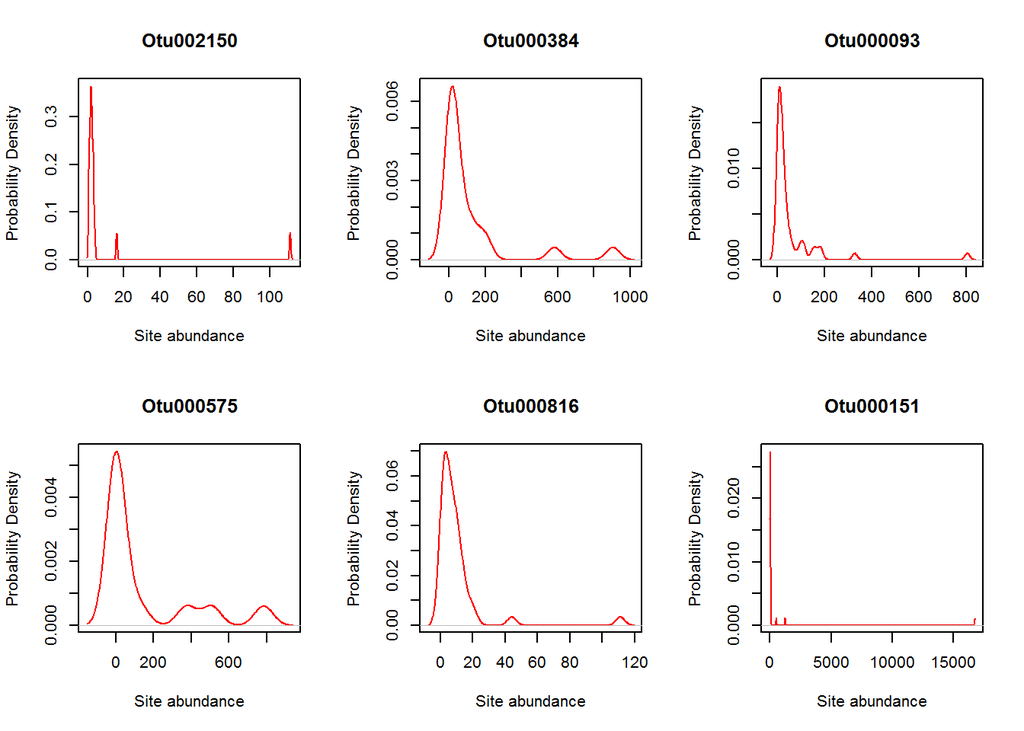

```r
# 1. Define an SSAD function
ssad <- function(x){
  ad <- c(2, 3)
  ad <- OTUs[, otu]
  ad = as.vector(t(x = ad))
  ad = ad[ad > 0]
}
# 2. Set plot parameters
par(mfrow=c(2, 3))

# 3. Declare a counter variable
ct <- 0
# 4. Write a while loop to plot the SSADs of six species chosen at random
while (ct < 6){
  otu <- sample(1:length(OTUs), 1) # random column
  ad <- ssad(otu) # find the OTU's SSAD
  if (length(ad) > 10 & sum(ad > 100)){ #if present in >10 sites with abundance >100, use this OTU
    ct <- ct + 1#and increment the counter
    plot(density(ad), col = 'red', xlab='Site abundance',
    ylab='Probability Density', main = otu.names[otu])
    }
  }
```

## 8) UNDERSTANDING SPATIAL SCALE

Many patterns of biodiversity relate to spatial scale.

*Question 9*: List, describe, and give examples of the two main aspects of spatial scale

> *Answer 9*: 1) Extent. This is the total geographic scale across all sites; extent will be defined by the sites at the most geographically-extreme locations. If there is one site in Hammerfest, one site in Nicosea, one in Lisbon, and one in Volgograd we can say that the extent of the dataset is all of Europe, and we could state it numerically (in meters^2) and geographically (in lat-lon coordinates).
> 2. Grain. This indicates how coarsely or finely resolved the dataset is. That is, the size of the individual sites in the sutdy determines the grain. For example, if the data in the above study were pooled such that Norway, Portugal, Cyprus, and Russia each constituted one study site, that would be a coarse grain; contrariwise, if there were many study sites within each country (e.g. each oblast in Russia or kommune in Norway), that would be a finer grain.

## 9) CONSTRUCTING THE SPECIES-AREA RELATIONSHIP

*Question 10*: In your own words, describe the species-area relationship.

> *Answer 10*:

> As the spatial extent of a study increases, so does the species richness. However, the rate at which richness increases for a given rate of increase of spatial extent is not constant across all spatial sizes. This can be represented as a power law S = cA^z— it is z which is not constant for all spatial extents.

> At first, at the local scale, richness increases rapidly (larger z) because new sub-ecosystems are being sampled—for example, imagine the plot begins in a forest. First increases simply capture new species because sampling effort was originally minimal, but subsequently as spatial extent increases the plot begins to encompass lakes, streams, open grassy areas. At the regional scale, these nearby sub-ecosystems have already been sampled and are added more slowly, so the richness increases more slowly, too (smaller z). However, as the spatial extent begins to encompass new biogeographic biomes (tundra; tropics; cacti AND phorbs), the rate of increase of richness speeds up again (larger z).

In the R code chunk below, provide the code to:

1. Simulate the spatial distribution of a community with 100 species, letting each species have between 1 and 1,000 individuals.

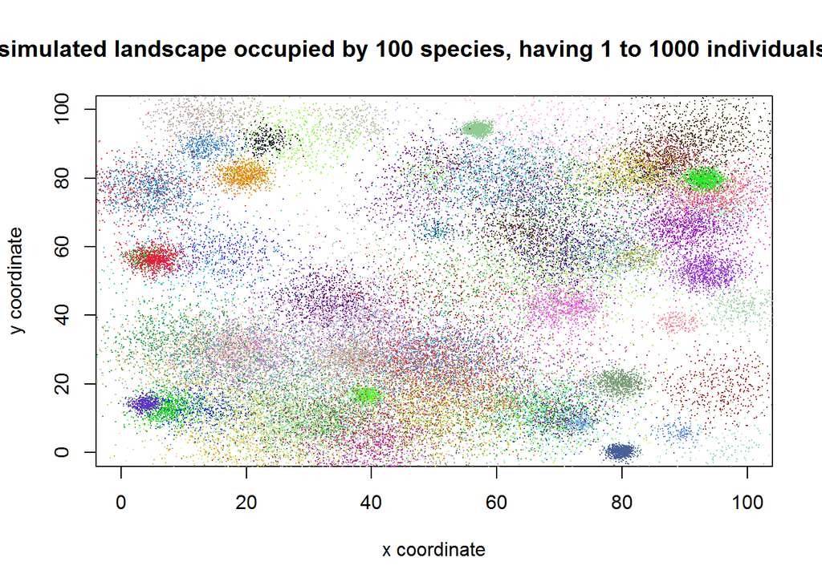

```r
# 1. Declare variables to hold simulated community and species information
community <- c() #empty community
species <- c() # empty species vector
# 2. Populate the simulated landscape

# initiate the plot
plot(0, 0, col='white', xlim = c(0, 100), ylim = c(0, 100), xlab='x coordinate', ylab='y coordinate', main='A simulated landscape occupied by 100 species, having 1 to 1000 individuals each.')
while (length(community) < 100){# choose the mean, standard deviation, and species color at random
  std <- runif(1, 1, 10) # random sample from a uniform distribution
  ab <- sample(1000, 1) # random number
  x <- rnorm(ab, mean = runif(1, 0, 100), sd = std) # 1000 random numbers from a Normal distribution for x values, centered at a random value (ab) (I think)
  y <- rnorm(ab, mean = runif(1, 0, 100), sd = std) # 1000 random numbers from a Normal distribution for y values, centered at a random value (ab)
  color <- c(rgb(runif(1),runif(1),runif(1))) # Let each species have a randomly chosen color
  points(x, y, pch=".", col=color) # Add points to a plot
  species <- list(x, y, color) # The species color, x-coords, and y-coords
  community[[length(community)+1]] <- species # Add the species' info to the community
}
```

While consult the handout for assistance, in the R chunk below, provide the code to:

1. Use a nested design to examine the SAR of our simulated community.
2. Plot the SAR and regression line.

```r
# 1. Declare the spatial extent and lists to hold species richness and area data
lim <- 10 # grain
S.list <- c() #spp vector
A.list <- c() #spatial scale vector
# 2. Construct a 'while' loop and 'for' loop combination to quantify the numbers of species for progressively larger areas of the simulated landscape.
while (lim <= 100){ # while the spatial extent <= 100...
  S <- 0 # initiate richness
  for (sp in community){ # for each species in the community
    xs <- sp[[1]] # assign the x coords
    ys <- sp[[2]] # assign the y coords
    sp.name <- sp[[3]] # assign the species name
    xy.coords <- cbind(xs, ys) # combine the columns for x and y coordinates
    for (xy in xy.coords){ # for each pair of xy coordinates
      if (max(xy) <= lim){ # if the individual is within our current spatial extent...
      S <- S + 1 # then the species occurs there
        break # break out of the last for loop because we now know the species occurs inside this sampling
        }
      }
    }
  S.list <- c(S.list, log10(S))
  A.list <- c(A.list, log10(lim^2))
  lim <- lim * 2 # increase the extent multiplicatively
  }
# 3. Be sure to log10-transform the richness and area data
#I did this within the while loop
```

In the R code chunk below, provide the code to:

1. Plot the richness and area data as a scatter plot.
2. Calculate and plot the regression line
3. Add a legend for the z-value (i.e., slope of the SAR)

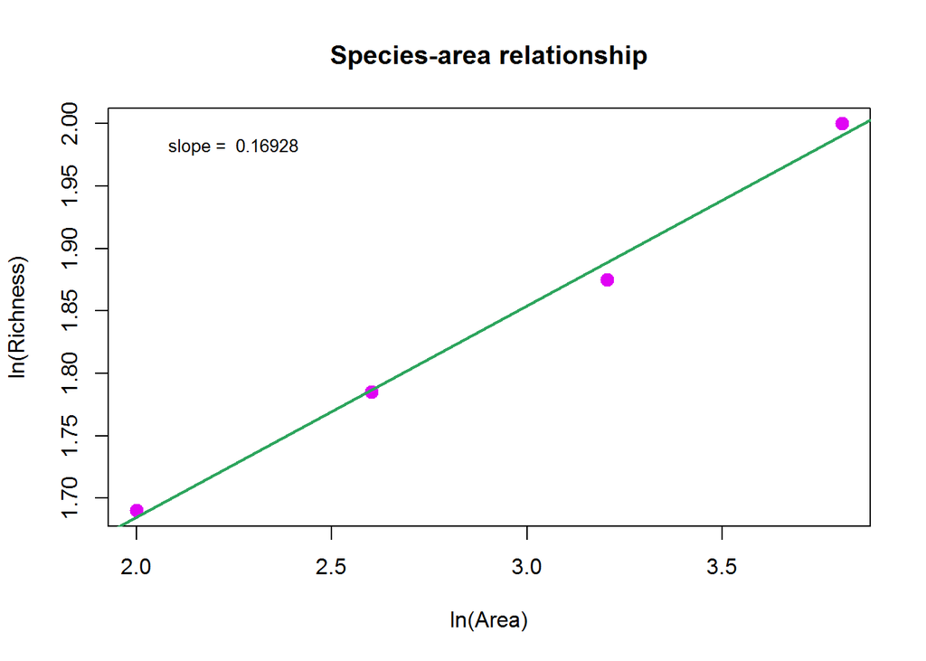

```r
results <- lm(S.list ~ A.list)
plot(A.list, S.list, col="#e003f4", pch=20, cex=2, main="Species-area relationship", xlab='ln(Area)', ylab='ln(Richness)')
abline(results, col="#2da55d", lwd=2)
int <- round(results[[1]][[1]],2)
z <- round(results[[1]][[2]],5)
legend(x=2, y=2, paste(c('slope = ', z), collapse = " "), cex=0.8,
box.lty=0)
```

*Question 10a*: Describe how richness relates to area in our simulated data by interpreting the slope of the SAR.

> *Answer 10a*:

*Question 10b*: What does the y-intercept of the SAR represent?

> *Answer 10b*:

> We used a plot in which ln(S) = ln(c) + z*ln(A). The intercept occurs where ln(A) = 0, or A = 1. So the intercept indicates the expected richness when the spatial area is unity. I think this means that this is the expected richness within the smallest grain, but I am not sure.

## SYNTHESIS

Load the dataset you are using for your project. Plot and discuss either the geogrpahic Distance-Decay relationship, the SSADs for at least four species, or any variant of the SAR (e.g., random accumulation of plots or areas, accumulation of contiguous plots or areas, nested design).

```r
plant<-read.csv("C:\\Users\\rmoge\\GitHub\\QB2017_DivPro\\Data\\HF_plants.csv",header=TRUE,sep=",")
#print(dim(plant))
#print(names(plant))

#install.packages("dplyr")
require(dplyr)
```

```r
plants.sortedT<-arrange(plant, treatment)
plants.sortedY<-arrange(plants.sortedT,year)
plants.sortedP<-arrange(plants.sortedY,plot)
my2009plants.sortedY<-filter(plants.sortedY, year==2009)
dim(my2009plants.sortedY)
```

```
## [1] 24 43
```

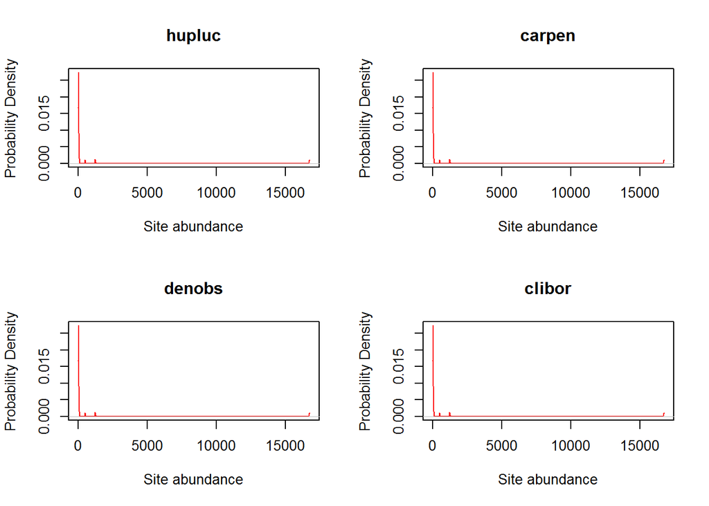

```r
sbs2009plants.sortedYt<-my2009plants.sortedY[4:43]
sbs2009plants.sortedYtt<-as.data.frame(sbs2009plants.sortedYt[-16,])

soilenv<-read.csv("C:\\Users\\rmoge\\GitHub\\QB2017_DivPro\\Data\\HF_soilresp.csv")
my2009soilenv<-filter(soilenv,year==2009,day==14,month==1)
temporary_soil<-my2009soilenv[-9]
sbs2009soilenv<-as.matrix(temporary_soil[8:11])
mycolnames<-colnames(sbs2009plants.sortedYtt, do.NULL = TRUE, prefix = "col")

# 2. Set plot parameters
par(mfrow=c(2, 2))

# 3. Declare a counter variable
ct <- 0
# 4. Write a while loop to plot the SSADs of 4 species chosen at random
while (ct < 4){
  tree.sp <- sample(1:length(sbs2009plants.sortedYtt), 1) # random column
  ad <- ssad(tree.sp) # find the OTU's SSAD
  #k <- arrayInd(tree.sp, dim(mdat))
  if (length(ad) > 2 & sum(ad > 2)){ #if present in >10 sites with abundance >100, use this species
    ct <- ct + 1#and increment the counter
    plot(density(ad), col = 'red', xlab='Site abundance',
    ylab='Probability Density', main = names(sbs2009plants.sortedYtt)[tree.sp])
    }
  }
```

> I selected the SSAD option because this dataset does not have geographic coordinate data.

> I could have done a random-accumulation-by site SAR, but I don’t think it would be very meaningful. All of the plots are, geographically, located in great proximity and the terrain is homogeneous. I don’t think doing a SAR would have much biological meaning, and if we saw a pattern it would be more likely to be a chance occurrence or a statistical pattern, rather than biological pattern.